# County Data Regression

## Intro + What is regression?

Regression is a task in machine learning that involves predicting continuous values for unseen examples given sets of features of training examples. This project takes a look at a number of regression experiments/techniques with American country data; that is, any data related to the socioeconomic state of the county (industry, population, education rate, etc.). The overall goal is to investigate how we can predict the poverty level of a county based on other county feature(s) to gain an understanding of what factors cause poverty across American counties. I hypothesize that a large number of factors, and likely some not represented in the dataset, will be responsible for the poverty level. Still, an investigation of the causes of poverty may go a long way towards alleviating it.

I'll be using evangambit's JsonOfCounties dataset from GitHub: https://github.com/evangambit/JsonOfCounties/tree/master. As mentioned, it contains several socioeconomic features of all counties in America. This dataset cites all of it's sources and appears reputable and well-maintained.

## Data Preprocessing (Experiment 1)

First, I'll load in the data that I'll be using:

```python
import pandas as pd

full_data = pd.read_csv("counties.csv")
print(full_data.shape)
full_data.head()
```

```
(3142, 237)
```

|  | name | fips | state | land_area (km^2) | area (km^2) | longitude (deg) | latitude (deg) | noaa/prcp | noaa/snow | noaa/temp | ... | industry/Agriculture, forestry, fishing and hunting/payroll | industry/Agriculture, forestry, fishing and hunting/employees | industry/Utilities/payroll | industry/Utilities/employees | industry/Management of companies and enterprises/payroll | industry/Management of companies and enterprises/employees | industry/Industries not classified/payroll | industry/Industries not classified/employees | industry/Mining, quarrying, and oil and gas extraction/payroll | industry/Mining, quarrying, and oil and gas extraction/employees |
| --- | --- | --- | --- | --- | --- | --- | --- | --- | --- | --- | --- | --- | --- | --- | --- | --- | --- | --- | --- | --- | --- |
| 0 | cuming county | 31039 | NE | 1477.641638 | 1488.343176 | -96.787366 | 41.916346 | 30.5 | 28.2 | 48.8 | ... | NaN | NaN | NaN | NaN | NaN | NaN | NaN | NaN | NaN | NaN |
| 1 | lancaster county | 31109 | NE | 2169.252486 | 2192.120047 | -96.688211 | 40.784132 | 31.0 | 25.3 | 51.0 | ... | 730000.0 | 111.0 | 8730000.0 | 95.0 | 165117000.0 | 2024.0 | 150000.0 | 3.0 | NaN | NaN |
| 2 | nuckolls county | 31129 | NE | 1489.645186 | 1491.363670 | -98.047277 | 40.176383 | 27.7 | 22.2 | 51.5 | ... | NaN | NaN | NaN | NaN | NaN | NaN | NaN | NaN | NaN | NaN |
| 3 | keith county | 31101 | NE | 2749.531887 | 2874.204062 | -101.657059 | 41.198294 | 20.0 | 25.0 | 50.0 | ... | NaN | NaN | NaN | NaN | NaN | NaN | NaN | NaN | NaN | NaN |
| 4 | phelps county | 31137 | NE | 1398.048570 | 1399.695104 | -99.414593 | 40.513105 | 25.5 | 26.7 | 50.3 | ... | 2557000.0 | 47.0 | NaN | NaN | NaN | NaN | NaN | NaN | NaN | NaN |

5 rows × 237 columns

Let's take a look at what features we have to work with:

```python
# Printing out the features in increments of fifteen, to avoid flooding the screen with output while also avoiding automatic data truncation
for i in range(0, len(full_data.columns), 30):
    if i+30 < len(full_data.columns):
        print(full_data.columns[i:i+30])
    else:
        print(full_data.columns[i:])
```

```
Index(['name', 'fips', 'state', 'land_area (km^2)', 'area (km^2)',
       'longitude (deg)', 'latitude (deg)', 'noaa/prcp', 'noaa/snow',
       'noaa/temp', 'noaa/altitude', 'noaa/temp-jan', 'noaa/temp-apr',
       'noaa/temp-jul', 'noaa/temp-oct', 'zip-codes',
       'race/non_hispanic_white_alone_male',
       'race/non_hispanic_white_alone_female', 'race/black_alone_male',
       'race/black_alone_female', 'race/asian_alone_male',
       'race/asian_alone_female', 'race/hispanic_male', 'race/hispanic_female',
       'age/0-4', 'age/5-9', 'age/10-14', 'age/15-19', 'age/20-24',
       'age/25-29'],
      dtype='object')
Index(['age/30-34', 'age/35-39', 'age/40-44', 'age/45-49', 'age/50-54',
       'age/55-59', 'age/60-64', 'age/65-69', 'age/70-74', 'age/75-79',
       'age/80-84', 'age/85+', 'male', 'female', 'population/2010',
       'population/2011', 'population/2012', 'population/2013',
       'population/2014', 'population/2015', 'population/2016',
       'population/2017', 'population/2018', 'population/2019',
       'deaths/suicides', 'deaths/firearm suicides', 'deaths/homicides',
       'deaths/vehicle', 'bls/2004/labor_force', 'bls/2004/employed'],
      dtype='object')
Index(['bls/2004/unemployed', 'bls/2008/labor_force', 'bls/2008/employed',
       'bls/2008/unemployed', 'bls/2012/labor_force', 'bls/2012/employed',
       'bls/2012/unemployed', 'bls/2016/labor_force', 'bls/2016/employed',
       'bls/2016/unemployed', 'bls/2020/labor_force', 'bls/2020/employed',
       'bls/2020/unemployed', 'life-expectancy',
       'fatal_police_shootings/total-2017',
       'fatal_police_shootings/unarmed-2017',
       'fatal_police_shootings/firearmed-2017',
       'fatal_police_shootings/total-2018',
       'fatal_police_shootings/unarmed-2018',
       'fatal_police_shootings/firearmed-2018',
       'fatal_police_shootings/total-2019',
       'fatal_police_shootings/unarmed-2019',
       'fatal_police_shootings/firearmed-2019',
       'fatal_police_shootings/total-2020',
       'fatal_police_shootings/unarmed-2020',
       'fatal_police_shootings/firearmed-2020', 'police_deaths', 'avg_income',
       'covid-deaths/2020-02-01', 'covid-deaths/2020-03-01'],
      dtype='object')
Index(['covid-deaths/2020-04-01', 'covid-deaths/2020-05-01',
```

[output cut: 78 more lines]

```
       'health/80th Percentile Income', 'health/20th Percentile Income',
       'health/% Children in Single-Parent Households',
       'health/Violent Crime Rate', 'health/Average Daily PM2.5',
       'health/% Severe Housing Problems', 'health/% Drive Alone to Work',
       'health/% Long Commute - Drives Alone',
       'industry/Agriculture, forestry, fishing and hunting/payroll',
       'industry/Agriculture, forestry, fishing and hunting/employees',
       'industry/Utilities/payroll', 'industry/Utilities/employees',
       'industry/Management of companies and enterprises/payroll',
       'industry/Management of companies and enterprises/employees',
       'industry/Industries not classified/payroll',
       'industry/Industries not classified/employees',
       'industry/Mining, quarrying, and oil and gas extraction/payroll',
       'industry/Mining, quarrying, and oil and gas extraction/employees'],
      dtype='object')
```

I'll make sure to remove the null rows for a feature or set of features for each experiment I do - I'll leave it as is for now.

For the first experiment, it would be insightful to predict the poverty rate using health metrics. It's well known that healthy foods (organic vegetables, fresh meats, etc.) are often more expensive than cheaply produced but often unhealthy foods. Might other lifestyle factors predict income? I'll look at several lifestyle features: % Smokers, % Physically Inactive, % Excessive Drinking, and the Food Environment Index (a general health metric that takes into account food desert status, access to healthy foods, and related things).

```python
health_data = full_data[["name", "health/% Smokers", "health/% Physically Inactive", "health/Food Environment Index", "health/% Excessive Drinking", "poverty-rate"]]
health_data.isna().sum()
```

```
name                              0
health/% Smokers                  1
health/% Physically Inactive      1
health/Food Environment Index    20
health/% Excessive Drinking       1
poverty-rate                      1
dtype: int64
```

Since there are so few null values, I'll just remove the counties with nulls from the data altogether.

```python
health_data = health_data.dropna()
health_data
```

|  | name | health/% Smokers | health/% Physically Inactive | health/Food Environment Index | health/% Excessive Drinking | poverty-rate |
| --- | --- | --- | --- | --- | --- | --- |
| 0 | cuming county | 16.269774 | 25.3 | 8.7 | 25.110453 | 8.9 |
| 1 | lancaster county | 16.430798 | 17.3 | 8.2 | 25.446613 | 10.7 |
| 2 | nuckolls county | 18.229344 | 31.3 | 7.2 | 22.103054 | 11.2 |
| 3 | keith county | 18.297152 | 28.3 | 7.8 | 24.073685 | 11.1 |
| 4 | phelps county | 16.168955 | 25.7 | 8.3 | 23.178963 | 10.0 |
| ... | ... | ... | ... | ... | ... | ... |
| 3137 | washington county | 16.234344 | 18.7 | 8.5 | 24.433705 | 8.0 |
| 3138 | providence county | 17.637069 | 25.4 | 8.2 | 18.585652 | 14.0 |
| 3139 | bristol county | 14.411364 | 19.0 | 8.2 | 20.289802 | 6.8 |
| 3140 | newport county | 14.879189 | 19.0 | 8.6 | 25.449361 | 8.5 |
| 3141 | kent county | 18.515666 | 23.4 | 8.5 | 20.421655 | 8.1 |

3121 rows × 6 columns

## Feature Visualization / Data Understanding (Experiment 1)

First, let's set up a basic correlation matrix for this data. Though we're strictly speaking only interested in the correlation between the health data and our target feature (poverty rate), it's interesting to see how other features are correlated to each other.

[output not shown]

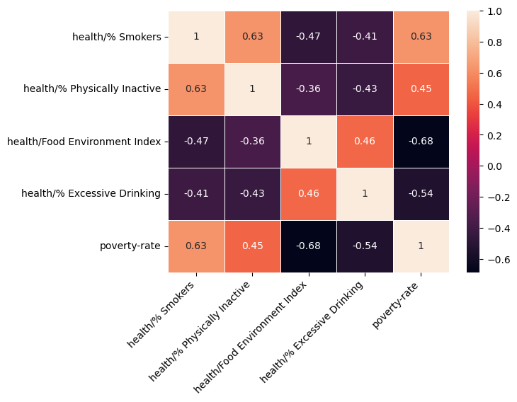

```python
import seaborn as sns
import matplotlib.pyplot as plt

corr_matrix = health_data.drop(columns=["name"]).corr()
sns.heatmap(corr_matrix, annot=True, linewidths=0.5)
plt.xticks(rotation=45, ha="right")
```

In experiment 2, I'll take a look at visualization and then linear regression using principal component analysis (PCA) to further understand the data, but let's try the feature set above first.

### Data Splits

For the last step in data preprocessing, I'll split the data into training and testing splits using a standard 80/20 scheme.

```python
from sklearn.model_selection import train_test_split

X = health_data.drop(columns=["name", "poverty-rate"])
y = health_data[["poverty-rate"]]

X_train, X_test, y_train, y_test = train_test_split(X, y, test_size=0.2)
X_train.shape, X_test.shape, y_train.shape, y_test.shape
```

```
((2496, 4), (625, 4), (2496, 1), (625, 1))
```

## Experiment 1: Linear Regression Modeling and Evaluation

### What is regression?, continued in greater detail:

First, I'll try a simple multiple linear regression using ordinary least squares. Multiple linear regression finds the weights of a linear equation ($y = mx + b$, or $J_{W}(x) = w_{1}x + w_{0}$) that best fits (yields the lowest error on) the training data. Multiple linear regression does not require gradient descent or any parameter estimation method, as the best weights are found through an analytical solution (known as *ordinary least squares*), which is derived by setting the derivative of the training error (mean squared error) to zero and solving for w. Since the derivative of the mean squared error function is convex, it only has one global minimum, and hence setting the derivative equal to zero and solving for the weights will yield the weights when the error is at the absolute minimum.

$$MSE: \frac{1}{N}\sum_{n=1}^{N}({y_{n, pred}-y_{n, true}})^{2}$$

where the prediction is: $$y_{n, pred}=w^{T}x_{n}$$ for some example feature vector $x_{n}$. The optimal weights found through setting the derivative of the mean squared error formula to zero and solving for w are: $$w_{optimal} = (X^{T}X)^{-1}X^{T}y$$

Scikit-learn's LinearRegression class uses ordinary least squares to fit the model to the data.

### Training

```python
from sklearn.linear_model import LinearRegression
from sklearn.metrics import mean_squared_error as mse
from sklearn.metrics import root_mean_squared_error as rmse

lr_model = LinearRegression(fit_intercept=True)
lr_model.fit(X_train, y_train)
```

```
LinearRegression()
```

### Evaluation

I'll use R^2 (explained below), MSE (explained/defined above), and root MSE (RMSE), which takes the square root of the MSE to normalize it to the units of the target feature (in our case, to the poverty rate).

```python
print(f"R^2: {lr_model.score(X_test, y_test)}")
```

```
R^2: 0.6402561952357052
```

```python
y_pred_Train = lr_model.predict(X_train)
print(f"Train MSE: {mse(y_train, y_pred_Train)}, Train RMSE: {rmse(y_train, y_pred_Train)}")  # RMSE is the normalized MSE.
y_pred_Test = lr_model.predict(X_test)
print(f"Test MSE: {mse(y_test, y_pred_Test)}, Test RMSE: {rmse(y_test, y_pred_Test)}")
```

```
Train MSE: 12.866172905929115, Train RMSE: 3.5869447871313986
Test MSE: 12.20079012335524, Test RMSE: 3.4929629433126315
```

It looks like our model predicts the target feature well, and also generalizes to unseen examples well, as the testing loss is similar to the training loss.

Now I'll plot the predicted and actual target values.

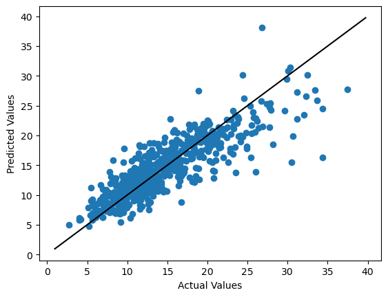

```python
import matplotlib.pyplot as plt
import numpy as np

plt.scatter(y_test, y_pred_Test)

# Using code snippet from reference https://stackoverflow.com/questions/25497402/adding-y-x-to-a-matplotlib-scatter-plot-if-i-havent-kept-track-of-all-the-data
# Intended to understand how to plot a y=x line for my plot below. To explain the code snippet I used, you would get the minimum and maximum limits of the data (lims)
# and plot a y=x line (x=lims and y=lims) across those bounds.
lims = [
    np.min([plt.gca().get_xlim(), plt.gca().get_ylim()]),
    np.max([plt.gca().get_xlim(), plt.gca().get_ylim()])
]
plt.plot(lims, lims, color="black")
plt.xlabel("Actual Values")
plt.ylabel("Predicted Values")
plt.show()
```

I can conclude from this experiment that these four features together make a moderately strong predictor of poverty, looking at the plot above and the fairly high R^2.

## Experiment 2: Principal Component Analysis (PCA): Good Idea?

Principal component analysis (PCA) is a dimensionality reduction technique that allows for high-dimensional data (with a large number of features) to be distilled into one or two (or any small number) of features. Though PCA is intended to distill a large number of features into a much smaller number, I'm curious how the technique will affect our scenario (where there are only four input features). Hopefully, it will at least provide a way of directly visualizing the data, impossible with four-dimensional data.

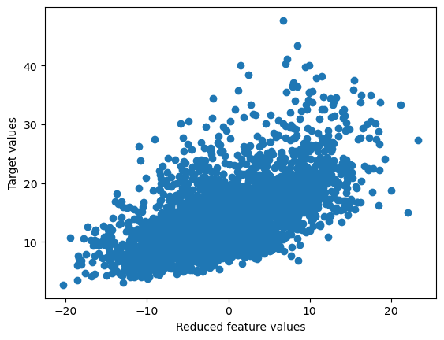

```python
from sklearn.decomposition import PCA

pca = PCA(n_components=1)
X = pca.fit_transform(X)
plt.scatter(X, y)
plt.xlabel("Reduced feature values")
plt.ylabel("Target values")
```

And the correlation between the PCA feature and target feature:

```python
pca_features = pd.DataFrame(X)
pca_features.columns = ["decomposed feature"]
pca_features["poverty rate"] = y

corr_matrix = pca_features.corr()
print(f"Correlation between PCA feature and target feature (poverty rate) {corr_matrix.iloc[0, 1]}")
```

```
Correlation between PCA feature and target feature (poverty rate) 0.26830089415612246
```

```python
X_train, X_test, y_train, y_test = train_test_split(X, y, test_size=0.2)

lr_model = LinearRegression(fit_intercept=True)
lr_model.fit(X_train, y_train)
print(f"R^2: {lr_model.score(X_test, y_test)}")
y_pred_Train = lr_model.predict(X_train)
print(f"Train MSE: {mse(y_train, y_pred_Train)}, Train RMSE: {rmse(y_train, y_pred_Train)}")
y_pred_Test = lr_model.predict(X_test)
print(f"Test MSE: {mse(y_test, y_pred_Test)}, Test RMSE: {rmse(y_test, y_pred_Test)}")
```

```
R^2: 0.35200702066481293
Train MSE: 22.4553262296772, Train RMSE: 4.738705121621011
Test MSE: 18.982375162830472, Test RMSE: 4.3568767670007
```

As suspected, the MSE and RMSE are much higher across the board than it was with the original four features. The R^2 is also nearly halved, showing that much less of the change in y is explained by the change in X. This experiment highlights the limits of PCA: that it is not always a viable option when looking to improve or visualize a regression experiment. Often, it can end in a massive loss of information, as seen here. PCA seems particularly useful or worthwhile only when the number of features is very high, much higher than the four used here.

## Experiment 3: Adding New Features

For the last experiment, I'll take a look at a new set of features for predicting our target feature, poverty rate (as it would be a shame not to use more of the large amount of data we started with). Since the four features used above seemed to all be excellent predictors of poverty rate, I'll leave them be and combine them with other features from the full dataset that I would hypothesize to also be predictors of poverty.

Let's try to combine the same health metrics with the county's education level and cost of living estimates.

```python
combined_data = full_data[["name",
                           "health/% Smokers",
                           "health/% Physically Inactive",
                           "health/Food Environment Index",
                           "health/% Excessive Drinking",
                           "edu/high-school",
                           "edu/some-college",
                           "edu/bachelors+",
                           "cost-of-living/living_wage",
                           "cost-of-living/food_costs",
                           "cost-of-living/medical_costs",
                           "cost-of-living/tax_costs",
                           "poverty-rate"]]
combined_data.isna().sum()
```

```
name                              0
health/% Smokers                  1
health/% Physically Inactive      1
health/Food Environment Index    20
health/% Excessive Drinking       1
edu/high-school                   0
edu/some-college                  0
edu/bachelors+                    0
cost-of-living/living_wage        0
cost-of-living/food_costs         0
cost-of-living/medical_costs      0
cost-of-living/tax_costs          0
poverty-rate                      1
dtype: int64
```

Similar to as before, I'll just drop all rows containing any null values, since there are so few of them.

```python
combined_data = combined_data.dropna()
combined_data.head()
```

|  | name | health/% Smokers | health/% Physically Inactive | health/Food Environment Index | health/% Excessive Drinking | edu/high-school | edu/some-college | edu/bachelors+ | cost-of-living/living_wage | cost-of-living/food_costs | cost-of-living/medical_costs | cost-of-living/tax_costs | poverty-rate |
| --- | --- | --- | --- | --- | --- | --- | --- | --- | --- | --- | --- | --- | --- |
| 0 | cuming county | 16.269774 | 25.3 | 8.7 | 25.110453 | 35.1 | 29.5 | 23.8 | 12.89 | 3246.0 | 2783.0 | 5385.0 | 8.9 |
| 1 | lancaster county | 16.430798 | 17.3 | 8.2 | 25.446613 | 21.5 | 32.6 | 39.5 | 14.72 | 3246.0 | 2783.0 | 7197.0 | 10.7 |
| 2 | nuckolls county | 18.229344 | 31.3 | 7.2 | 22.103054 | 34.0 | 37.0 | 20.9 | 12.89 | 3246.0 | 2783.0 | 5385.0 | 11.2 |
| 3 | keith county | 18.297152 | 28.3 | 7.8 | 24.073685 | 31.7 | 39.3 | 20.5 | 13.40 | 3246.0 | 2783.0 | 5584.0 | 11.1 |
| 4 | phelps county | 16.168955 | 25.7 | 8.3 | 23.178963 | 29.9 | 39.9 | 23.5 | 12.89 | 3246.0 | 2783.0 | 5385.0 | 10.0 |

Following the same procedure from here on as experiment 1:

```
R^2: 0.7054001633317839
Train MSE: 10.434463518361193, Train RMSE: 3.2302420216388112
Test MSE: 10.327115917713423, Test RMSE: 3.2135830342023874
```

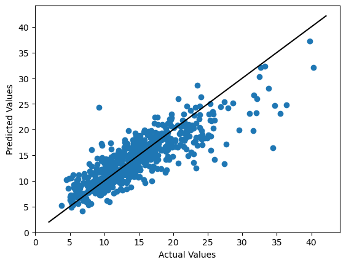

```python
X = combined_data.drop(columns=["name", "poverty-rate"])
y = combined_data[["poverty-rate"]]

X_train, X_test, y_train, y_test = train_test_split(X, y, test_size=0.2)
X_train.shape, X_test.shape, y_train.shape, y_test.shape

lr_model = LinearRegression(fit_intercept=True)
lr_model.fit(X_train, y_train)
print(f"R^2: {lr_model.score(X_test, y_test)}")

y_pred_Train = lr_model.predict(X_train)
print(f"Train MSE: {mse(y_train, y_pred_Train)}, Train RMSE: {rmse(y_train, y_pred_Train)}")
y_pred_Test = lr_model.predict(X_test)
print(f"Test MSE: {mse(y_test, y_pred_Test)}, Test RMSE: {rmse(y_test, y_pred_Test)}")

plt.scatter(y_test, y_pred_Test)

# Using code snippet from reference https://stackoverflow.com/questions/25497402/adding-y-x-to-a-matplotlib-scatter-plot-if-i-havent-kept-track-of-all-the-data
lims = [
    np.min([plt.gca().get_xlim(), plt.gca().get_ylim()]),
    np.max([plt.gca().get_xlim(), plt.gca().get_ylim()]),
]
plt.plot(lims, lims, color="black")
plt.xlabel("Actual Values")
plt.ylabel("Predicted Values")
plt.show()
```

Excellent - as we've added more information, the R^2 value has increased over experiment 1. The input features now seem to better explain changes in the target feature. Our MSE and RMSE are now slightly lower than in experiment 1 as well. Interestingly, in both experiment 1 and 3, the model seems to have a more difficult time predicting outliers with high rates of poverty. Notice above how, as the actual poverty rate increases above 30, the predicted poverty rate fails to keep up. This could be due to a simple lack of examples of extreme poverty rates, or an indication that specifically extreme poverty is predicted by other factors, or a combination of both.

## Impact

As mentioned in the introduction, a strong understanding of what factors contribute to changes in the poverty rate of counties across America is essential to combating poverty. Predicting the poverty rate using a regression model may become relevant if the poverty rate is ever unavailable for a county, or if the Census Bureau (the organization responsible for calculating the poverty rate used in this dataset) ever intends to re-examine how they determine the value. According to https://www.census.gov/programs-surveys/saipe/technical-documentation/methodology.html, this methodology is revisited occasionally.

A potential negative impact of my methodology is that it may, to some extent, decontextualize the county's situation regarding poverty. Not all the information that explains a county's poverty level is available, and possibly not all of it can even be quantified, so this project is reductive in that sense. Furthermore, it could be incorrectly construed that some feature causes poverty completely or nearly completely, when really it is only one of many factors *correlated* with poverty. I don't wish to create the harmful stereotype that, for example, a low education rate guarantees a high poverty rate. Correlation is not causation!

## Conclusion

I also tried principal component analysis (PCA) on the health/lifestyle features I used in my first experiment, finding empirically that PCA was a poor choice for that scenario, likely due to the relatively small number of initial features. I've come away with a greater understanding of when to consider using PCA, and how to determine the effect it's having on a dataset.

Zooming out, I've learned a lot about feature selection in regression experiments, regression metrics (R^2, MSE/RMSE), and techniques of visualizing/understanding continuous data (e.g., PCA).

### References:

Sklearn documentation, pandas documentation, Overleaf LaTeX documentation, matplotlib/seaborn documentation

https://stackoverflow.com/questions/26266362/how-do-i-count-the-nan-values-in-a-column-in-pandas-dataframe https://pandas.pydata.org/docs/reference/api/pandas.DataFrame.dropna.html https://stackoverflow.com/questions/493386/how-to-print-without-a-newline-or-space https://seaborn.pydata.org/examples/many_pairwise_correlations.html https://stackoverflow.com/questions/10998621/rotate-axis-tick-labels https://en.wikipedia.org/wiki/Coefficient_of_determination https://stackoverflow.com/questions/58410187/how-to-plot-predicted-values-vs-the-true-value https://medium.com/@VitorCSampaio/understanding-ordinary-least-squares-ols-the-foundation-of-linear-regression-1d79bfc3ca35 https://en.wikipedia.org/wiki/Ordinary_least_squares https://stackoverflow.com/questions/41709257/how-to-change-the-plot-line-color-from-blue-to-black